# 6. Obesity Percentage with Tax

### Importing necessary libraries

```python
import pandas as pd
import numpy as np
import seaborn as sns
import matplotlib.pyplot as plt
import statsmodels.api as sm

# code to ignore warnings
import warnings
warnings.filterwarnings("ignore")

root_csv = '../csv files/'
root_pickle = '../pickle files/'
```

### Reading files

```python
df_obese_total_pivot = pd.read_pickle(root_pickle +'Obesity_Total_Pivot.pkl')
df_obese_gender_pivot = pd.read_pickle(root_pickle +'Obesity_Gender_Pivot.pkl')
df_obese_age_pivot = pd.read_pickle(root_pickle +'Obesity_Age_Pivot.pkl')
```

### Reviewing data

```python
df_obese_total_pivot.head(5)
```

|  | State | County | CountyFIPS | Year | Total Absolute | Total Percentage | Grocery Tax | Restaurant Tax | tax_delta | Population |
| --- | --- | --- | --- | --- | --- | --- | --- | --- | --- | --- |
| 0 | Alabama | Autauga County | 1001 | 2004 | 7213.0 | 21.9 | 0.04 | 0.04 | 0.0 | 32936.073633 |
| 6 | Alabama | Autauga County | 1001 | 2005 | 8093.0 | 24.0 | 0.04 | 0.04 | 0.0 | 33720.833333 |
| 12 | Alabama | Autauga County | 1001 | 2006 | 7457.0 | 21.5 | 0.04 | 0.04 | 0.0 | 34683.720930 |
| 18 | Alabama | Autauga County | 1001 | 2007 | 7467.0 | 21.1 | 0.04 | 0.04 | 0.0 | 35388.624953 |
| 24 | Alabama | Autauga County | 1001 | 2008 | 9568.0 | 26.6 | 0.04 | 0.04 | 0.0 | 35969.924296 |

```python
df_obese_gender_pivot.head(5)
```

|  | State | County | CountyFIPS | Year | Gender Absolute | Gender Percentage | Gender | Grocery Tax | Restaurant Tax | tax_delta | Population |
| --- | --- | --- | --- | --- | --- | --- | --- | --- | --- | --- | --- |
| 0 | Alabama | Autauga County | 1001 | 2004 | 3747.0 | 21.700001 | Female | 0.04 | 0.04 | 0.0 | 17267.280499 |
| 3 | Alabama | Autauga County | 1001 | 2004 | 3466.0 | 22.100000 | Male | 0.04 | 0.04 | 0.0 | 15683.257648 |
| 6 | Alabama | Autauga County | 1001 | 2005 | 4141.0 | 23.400000 | Female | 0.04 | 0.04 | 0.0 | 17696.581485 |
| 9 | Alabama | Autauga County | 1001 | 2005 | 3952.0 | 24.600000 | Male | 0.04 | 0.04 | 0.0 | 16065.040401 |
| 12 | Alabama | Autauga County | 1001 | 2006 | 3874.0 | 21.299999 | Female | 0.04 | 0.04 | 0.0 | 18187.794079 |

```python
df_obese_age_pivot.head(5)
```

|  | State | County | CountyFIPS | Year | Age Obesity Absolute | Age Obesity Percentage | Age | Grocery Tax | Restaurant Tax | tax_delta | Population |
| --- | --- | --- | --- | --- | --- | --- | --- | --- | --- | --- | --- |
| 0 | Alabama | Autauga County | 1001 | 2004 | 3411.0 | 20.700001 | 20-44 | 0.04 | 0.04 | 0.0 | 16478.260262 |
| 1 | Alabama | Autauga County | 1001 | 2004 | 2898.0 | 25.299999 | 45-64 | 0.04 | 0.04 | 0.0 | 11454.545800 |
| 2 | Alabama | Autauga County | 1001 | 2004 | 904.0 | 17.900000 | 65-beyond | 0.04 | 0.04 | 0.0 | 5050.279437 |
| 6 | Alabama | Autauga County | 1001 | 2005 | 3714.0 | 22.200001 | 20-44 | 0.04 | 0.04 | 0.0 | 16729.729155 |
| 7 | Alabama | Autauga County | 1001 | 2005 | 3379.0 | 28.500000 | 45-64 | 0.04 | 0.04 | 0.0 | 11856.140351 |

### Regression Analysis at County level data

#### 1. Baseline without controls

##### a. With Total Percentage as Response Variable:

```python
import numpy as np
import pandas as pd
import statsmodels.api as sm
from sklearn.model_selection import train_test_split
from sklearn.linear_model import LinearRegression
from sklearn.metrics import mean_squared_error, r2_score

# Assuming 'Grocery Tax' and 'Restaurant Tax' are the features
X = df_obese_total_pivot[['Grocery Tax', 'Restaurant Tax']]
y = df_obese_total_pivot['Total Percentage']

# Add a constant term to the features matrix (required for statsmodels)
X = sm.add_constant(X)

# Create and fit the linear regression model using statsmodels
stats_model = sm.OLS(y, X).fit()

# Print the summary
print(stats_model.summary())
```

```
                            OLS Regression Results
==============================================================================
Dep. Variable:       Total Percentage   R-squared:                       0.008
Model:                            OLS   Adj. R-squared:                  0.008
Method:                 Least Squares   F-statistic:                     228.1
Date:                Sun, 26 Nov 2023   Prob (F-statistic):           2.35e-99
Time:                        07:39:30   Log-Likelihood:            -1.6085e+05
No. Observations:               53352   AIC:                         3.217e+05
Df Residuals:                   53349   BIC:                         3.217e+05
Df Model:                           2
Covariance Type:            nonrobust
==================================================================================
                     coef    std err          t      P>|t|      [0.025      0.975]
----------------------------------------------------------------------------------
const             24.4510      0.070    351.310      0.000      24.315      24.587
Grocery Tax       15.5025      1.027     15.093      0.000      13.489      17.516
Restaurant Tax    16.4089      1.277     12.845      0.000      13.905      18.913
==============================================================================
Omnibus:                     1197.133   Durbin-Watson:                   0.643
Prob(Omnibus):                  0.000   Jarque-Bera (JB):             1269.058
Skew:                           0.372   Prob(JB):                    2.68e-276
Kurtosis:                       2.873   Cond. No.                         60.9
==============================================================================

Notes:
[1] Standard Errors assume that the covariance matrix of the errors is correctly specified.
```

##### Conclusions:

The baseline model with response as total percentage of Obesity and predictor variables grocery tax and restaurant tax:

- One percent increase in grocery tax, keeping all other constant, increases the percentage of Obesity by 15.50%
- One percent increase in restaurant tax, keeping all other constant, increases the percentage of Obesity by 16.40%
- p-value is close to 0 in both cases. Hence the coefficients of regression are statistically significant
- Adjusted R-square is 0.008 indicating that the model can explain only 0.8% of variation in total number of Obesity patient
- This model was fitted without taking into account affects of other factors such as age, gender, ethinicity etc.

#### 2. With single controls

##### a. Gender Control - On Percentage

```python
import numpy as np
import pandas as pd
import statsmodels.api as sm
from sklearn.model_selection import train_test_split
from sklearn.linear_model import LinearRegression
from sklearn.metrics import mean_squared_error, r2_score

# One Hot Encoding Gender in predictor variable
X = pd.get_dummies(df_obese_gender_pivot[['Grocery Tax', 'Restaurant Tax', 'Gender']], columns=['Gender'], drop_first=True)
y = df_obese_gender_pivot['Gender Percentage']

# Add a constant term to the features matrix (required for statsmodels)
X = sm.add_constant(X)

# Create and fit the linear regression model using statsmodels
stats_model = sm.OLS(y, X).fit()

# Print the summary
print(stats_model.summary())
```

```
                            OLS Regression Results
==============================================================================
Dep. Variable:      Gender Percentage   R-squared:                       0.017
Model:                            OLS   Adj. R-squared:                  0.017
Method:                 Least Squares   F-statistic:                     626.8
Date:                Sun, 26 Nov 2023   Prob (F-statistic):               0.00
Time:                        07:39:30   Log-Likelihood:            -3.2305e+05
No. Observations:              106702   AIC:                         6.461e+05
Df Residuals:                  106698   BIC:                         6.461e+05
Df Model:                           3
Covariance Type:            nonrobust
==================================================================================
                     coef    std err          t      P>|t|      [0.025      0.975]
----------------------------------------------------------------------------------
const             23.9591      0.052    459.524      0.000      23.857      24.061
Grocery Tax       15.6919      0.736     21.332      0.000      14.250      17.134
Restaurant Tax    15.8104      0.915     17.282      0.000      14.017      17.604
Gender_Male        0.9703      0.031     31.719      0.000       0.910       1.030
==============================================================================
Omnibus:                     2817.425   Durbin-Watson:                   0.403
Prob(Omnibus):                  0.000   Jarque-Bera (JB):             3047.203
Skew:                           0.414   Prob(JB):                         0.00
Kurtosis:                       2.989   Cond. No.                         69.7
==============================================================================

Notes:
[1] Standard Errors assume that the covariance matrix of the errors is correctly specified.
```

##### b. Age Control - On Percentage

```python
import numpy as np
import pandas as pd
import statsmodels.api as sm
from sklearn.model_selection import train_test_split
from sklearn.linear_model import LinearRegression
from sklearn.metrics import mean_squared_error, r2_score

# One Hot Encoding Gender in predictor variable
X = pd.get_dummies(df_obese_age_pivot[['Grocery Tax', 'Restaurant Tax', 'Age']], columns=['Age'], drop_first=True)
y = df_obese_age_pivot['Age Obesity Percentage']

# Add a constant term to the features matrix (required for statsmodels)
X = sm.add_constant(X)

# Create and fit the linear regression model using statsmodels
stats_model = sm.OLS(y, X).fit()

# Print the summary
print(stats_model.summary())
```

```
                              OLS Regression Results
==================================================================================
Dep. Variable:     Age Obesity Percentage   R-squared:                       0.280
Model:                                OLS   Adj. R-squared:                  0.280
Method:                     Least Squares   F-statistic:                 1.555e+04
Date:                    Sun, 26 Nov 2023   Prob (F-statistic):               0.00
Time:                            07:39:30   Log-Likelihood:            -4.8437e+05
No. Observations:                  159995   AIC:                         9.688e+05
Df Residuals:                      159990   BIC:                         9.688e+05
Df Model:                               4
Covariance Type:                nonrobust
==================================================================================
                     coef    std err          t      P>|t|      [0.025      0.975]
----------------------------------------------------------------------------------
const             22.6270      0.044    509.953      0.000      22.540      22.714
Grocery Tax       15.0727      0.601     25.096      0.000      13.895      16.250
Restaurant Tax    18.6006      0.747     24.896      0.000      17.136      20.065
Age_45-64          5.6360      0.031    184.271      0.000       5.576       5.696
Age_65-beyond     -1.5178      0.031    -49.611      0.000      -1.578      -1.458
==============================================================================
Omnibus:                     4043.584   Durbin-Watson:                   0.268
Prob(Omnibus):                  0.000   Jarque-Bera (JB):             4356.499
Skew:                           0.404   Prob(JB):                         0.00
Kurtosis:                       2.956   Cond. No.                         68.0
==============================================================================

Notes:
[1] Standard Errors assume that the covariance matrix of the errors is correctly specified.
```

##### Conclusion:

The model with response as percentage of Obesity and predictor variables grocery tax and restaurant tax and control on age:

- One percent increase in grocery tax, keeping all other constant, increases the percentage by 15.07%
- One percent increase in restaurant tax, keeping all other constant, increases the percentage by 18.6006%
- If the age is between 45-64, keeping all other constant, the percentage increases by 5.63%.
- If the age is between 65-beyond, keeping all other constant, the percentage decreases by 1.51%.
- All p values are statistically significant
- Adjusted R-square is 0.28 indicating that the model can explain only 28% of variation in percentage of Obesity patient
- There is a significant increase in R-square. Since we fit linear model, we will have to validate its assumptions

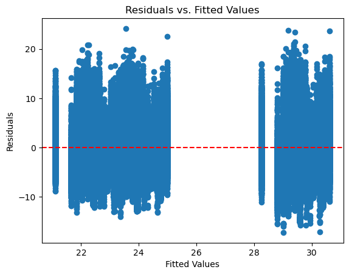

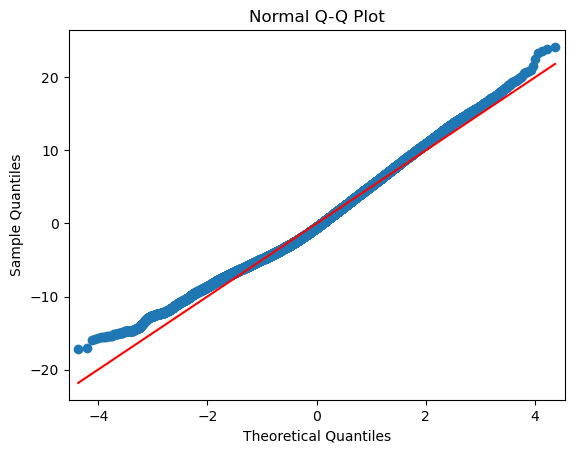

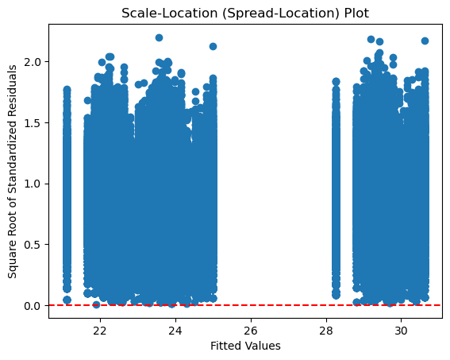

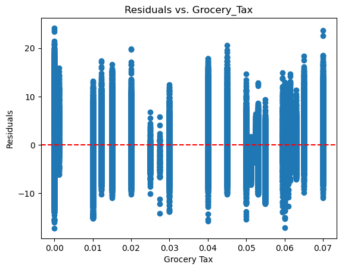

```python
# Checking linearity assumptions

import statsmodels.api as sm
import matplotlib.pyplot as plt
import scipy.stats as stats
import numpy as np

# Assuming you have already fitted the linear regression model named 'model'

# Get fitted values and residuals
fitted_values = stats_model.fittedvalues
residuals = stats_model.resid

# 1. Residuals vs. Fitted Values Plot
plt.scatter(fitted_values, residuals)
plt.xlabel('Fitted Values')
plt.ylabel('Residuals')
plt.title('Residuals vs. Fitted Values')
plt.axhline(y=0, color='r', linestyle='--')  # Add a horizontal line at y=0
plt.show()

# 2. Normal Q-Q Plot
sm.qqplot(residuals, line='s')
plt.title('Normal Q-Q Plot')
plt.show()

# 3. Scale-Location (Spread-Location) Plot
sqrt_standardized_residuals = np.sqrt(np.abs(stats_model.get_influence().resid_studentized_internal))
plt.scatter(fitted_values, sqrt_standardized_residuals)
plt.xlabel('Fitted Values')
plt.ylabel('Square Root of Standardized Residuals')
plt.title('Scale-Location (Spread-Location) Plot')
plt.axhline(y=0, color='r', linestyle='--')  # Add a horizontal line at y=0
plt.show()

# 4. Residuals vs. Predictor Plot for 'Grocery Tax'
plt.scatter(df_obese_age_pivot['Grocery Tax'], residuals)
plt.xlabel('Grocery Tax')
plt.ylabel('Residuals')
plt.title('Residuals vs. Grocery_Tax')
plt.axhline(y=0, color='r', linestyle='--')  # Add a horizontal line at y=0
plt.show()
```

##### Conclusions:

For the control model with age on response variable percentage Obesity, we observe that the assumptions are violated. Hence, we are applying transformation to provide remedy.

```python
#### Applying the Box-Cox transformation

# Apply Box-Cox Transformation to Response Variable
y_transformed, lambda_value = stats.boxcox(y + 1)  # Adding 1 to handle zero values

# Visualize the Transformed Response Variable
plt.hist(y_transformed, bins=20, edgecolor='black')
plt.title('Histogram of Transformed Response Variable')
plt.show()

# Check Lambda Value
print(f'Lambda Value: {lambda_value}')

# Fit a new model using the transformed response variable
stats_model_transformed = sm.OLS(y_transformed, X).fit()

# Print the summary of the transformed model
print(stats_model_transformed.summary())
```

[output not shown]

```
Lambda Value: 0.14805832959442175
                            OLS Regression Results
==============================================================================
Dep. Variable:                      y   R-squared:                       0.275
Model:                            OLS   Adj. R-squared:                  0.275
Method:                 Least Squares   F-statistic:                 1.515e+04
Date:                Sun, 26 Nov 2023   Prob (F-statistic):               0.00
Time:                        07:39:36   Log-Likelihood:                -39599.
No. Observations:              159995   AIC:                         7.921e+04
Df Residuals:                  159990   BIC:                         7.926e+04
Df Model:                           4
Covariance Type:            nonrobust
==================================================================================
                     coef    std err          t      P>|t|      [0.025      0.975]
----------------------------------------------------------------------------------
const              4.0166      0.003   1459.017      0.000       4.011       4.022
Grocery Tax        0.9900      0.037     26.568      0.000       0.917       1.063
Restaurant Tax     1.0786      0.046     23.268      0.000       0.988       1.169
Age_45-64          0.3364      0.002    177.293      0.000       0.333       0.340
Age_65-beyond     -0.1054      0.002    -55.515      0.000      -0.109      -0.102
==============================================================================
Omnibus:                      342.862   Durbin-Watson:                   0.290
Prob(Omnibus):                  0.000   Jarque-Bera (JB):              275.860
Skew:                          -0.003   Prob(JB):                     1.25e-60
Kurtosis:                       2.797   Cond. No.                         68.0
==============================================================================

Notes:
[1] Standard Errors assume that the covariance matrix of the errors is correctly specified.
```

##### Conclusions:

- The lambda value of transformation is 0.14
- For this lambda value, the model response variable (y) = % Obesity is now transformed to (((y^0.14)-1)/0.14) or (((% Obesity^0.14)-1)/0.14)
- This changes some of the inferences. ##### New Inferences:
- A one unit increase in grocery tax increases transformed y by 0.99%
- A one unit increase in restaurant tax increases transformed y by 1.07%
- If the age bucket is 45-65, there is an increase in transformed y by 0.33%
- If the age bucket is 65-beyond, there is an decrease in transformed y by 0.10%
- Adj R-square is 27.5% indicating the model explains 27.5% variability in transformed y.

##### c. Total Population Control - On Percentage

```python
import numpy as np
import pandas as pd
import statsmodels.api as sm
from sklearn.model_selection import train_test_split
from sklearn.linear_model import LinearRegression
from sklearn.metrics import mean_squared_error, r2_score

# Assuming 'Grocery Tax' and 'Restaurant Tax' are the features
X = df_obese_total_pivot[['Grocery Tax', 'Restaurant Tax','Population']]
y = df_obese_total_pivot['Total Percentage']

# Add a constant term to the features matrix (required for statsmodels)
X = sm.add_constant(X)

# Create and fit the linear regression model using statsmodels
stats_model = sm.OLS(y, X).fit()

# Print the summary
print(stats_model.summary())
```

```
                            OLS Regression Results
==============================================================================
Dep. Variable:       Total Percentage   R-squared:                       0.010
Model:                            OLS   Adj. R-squared:                  0.010
Method:                 Least Squares   F-statistic:                     175.6
Date:                Sun, 26 Nov 2023   Prob (F-statistic):          2.78e-113
Time:                        07:39:36   Log-Likelihood:            -1.6081e+05
No. Observations:               53352   AIC:                         3.216e+05
Df Residuals:                   53348   BIC:                         3.217e+05
Df Model:                           3
Covariance Type:            nonrobust
==================================================================================
                     coef    std err          t      P>|t|      [0.025      0.975]
----------------------------------------------------------------------------------
const             24.4315      0.070    351.059      0.000      24.295      24.568
Grocery Tax       16.4022      1.032     15.892      0.000      14.379      18.425
Restaurant Tax    15.4940      1.281     12.092      0.000      12.983      18.005
Population      7.666e-07   9.16e-08      8.367      0.000    5.87e-07    9.46e-07
==============================================================================
Omnibus:                     1212.665   Durbin-Watson:                   0.643
Prob(Omnibus):                  0.000   Jarque-Bera (JB):             1288.344
Skew:                           0.376   Prob(JB):                    1.74e-280
Kurtosis:                       2.881   Cond. No.                     1.51e+07
==============================================================================

Notes:
[1] Standard Errors assume that the covariance matrix of the errors is correctly specified.
[2] The condition number is large, 1.51e+07. This might indicate that there are
strong multicollinearity or other numerical problems.
```

##### Conclusion:

The model with response as % of Obesity and predictor variable tax and control on population:

```python
# Checking for multicollinearity
from statsmodels.stats.outliers_influence import variance_inflation_factor

vif_data = pd.DataFrame()
vif_data["Variable"] = X.columns
vif_data["VIF"] = [variance_inflation_factor(X.values, i) for i in range(X.shape[1])]

# Check the VIF values
print(vif_data)
```

```
         Variable        VIF
0           const  10.632575
1     Grocery Tax   1.031262
2  Restaurant Tax   1.027550
3      Population   1.016111
```

##### Inference:

The VIF for predictor variables is small and hence multicollinearity does not exist The VIF with constant variable is high. This can be fixed by scaling if needed.

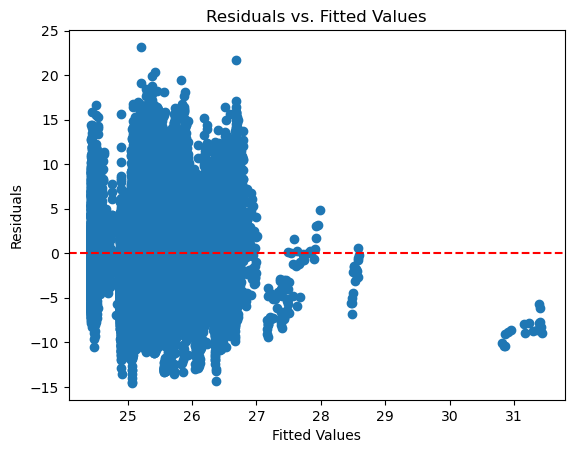

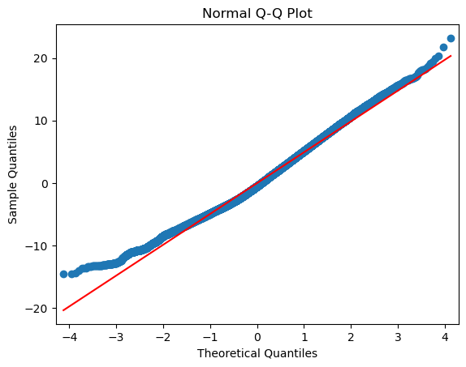

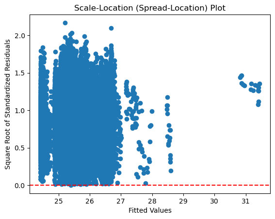

[figure not shown]

```python
# Validating for linearity assumptions

import statsmodels.api as sm
import matplotlib.pyplot as plt
import scipy.stats as stats
import numpy as np

# Assuming you have already fitted the linear regression model named 'model'

# Get fitted values and residuals
fitted_values = stats_model.fittedvalues
residuals = stats_model.resid

# 1. Residuals vs. Fitted Values Plot
plt.scatter(fitted_values, residuals)
plt.xlabel('Fitted Values')
plt.ylabel('Residuals')
plt.title('Residuals vs. Fitted Values')
plt.axhline(y=0, color='r', linestyle='--')  # Add a horizontal line at y=0
plt.show()

# 2. Normal Q-Q Plot
sm.qqplot(residuals, line='s')
plt.title('Normal Q-Q Plot')
plt.show()

# 3. Scale-Location (Spread-Location) Plot
sqrt_standardized_residuals = np.sqrt(np.abs(stats_model.get_influence().resid_studentized_internal))
plt.scatter(fitted_values, sqrt_standardized_residuals)
plt.xlabel('Fitted Values')
plt.ylabel('Square Root of Standardized Residuals')
plt.title('Scale-Location (Spread-Location) Plot')
plt.axhline(y=0, color='r', linestyle='--')  # Add a horizontal line at y=0
plt.show()

# 4. Residuals vs. Predictor Plot for ''
plt.scatter(df_obese_total_pivot['Population'], residuals)
plt.xlabel('Population')
plt.ylabel('Residuals')
plt.title('Residuals vs. Tax Delta')
plt.axhline(y=0, color='r', linestyle='--')  # Add a horizontal line at y=0
plt.show()
```

##### Since the above model violates linearity assumptions, applying Box-Cox transformation

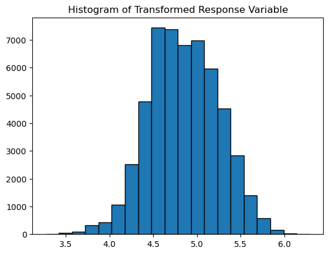

```
Lambda Value: 0.22847486523614613
                            OLS Regression Results
==============================================================================
Dep. Variable:                      y   R-squared:                       0.010
Model:                            OLS   Adj. R-squared:                  0.010
Method:                 Least Squares   F-statistic:                     180.7
Date:                Sun, 26 Nov 2023   Prob (F-statistic):          1.45e-116
Time:                        07:39:39   Log-Likelihood:                -25866.
No. Observations:               53352   AIC:                         5.174e+04
Df Residuals:                   53348   BIC:                         5.178e+04
Df Model:                           3
Covariance Type:            nonrobust
==================================================================================
                     coef    std err          t      P>|t|      [0.025      0.975]
----------------------------------------------------------------------------------
const              4.7684      0.006    859.595      0.000       4.758       4.779
Grocery Tax        1.3922      0.082     16.923      0.000       1.231       1.553
Restaurant Tax     1.1172      0.102     10.939      0.000       0.917       1.317
Population      6.688e-08    7.3e-09      9.157      0.000    5.26e-08    8.12e-08
==============================================================================
Omnibus:                      107.530   Durbin-Watson:                   0.655
Prob(Omnibus):                  0.000   Jarque-Bera (JB):               87.197
Skew:                           0.002   Prob(JB):                     1.16e-19
Kurtosis:                       2.802   Cond. No.                     1.51e+07
==============================================================================

Notes:
[1] Standard Errors assume that the covariance matrix of the errors is correctly specified.
[2] The condition number is large, 1.51e+07. This might indicate that there are
strong multicollinearity or other numerical problems.
```

```python
# Applying the Box-Cox transformation

# Apply Box-Cox Transformation to Response Variable
y_transformed, lambda_value = stats.boxcox(y + 1)  # Adding 1 to handle zero values

# Visualize the Transformed Response Variable
plt.hist(y_transformed, bins=20, edgecolor='black')
plt.title('Histogram of Transformed Response Variable')
plt.show()

# Check Lambda Value
print(f'Lambda Value: {lambda_value}')

# Fit a new model using the transformed response variable
stats_model_transformed = sm.OLS(y_transformed, X).fit()

# Print the summary of the transformed model
print(stats_model_transformed.summary())
```

##### Since, we do not get a good R-square value, even after fixing assumtpions by transforming, we drop further investigation.

#### 3. With multiple controls

##### a. Total Population and Gender - On Percentage

```python
import numpy as np
import pandas as pd
import statsmodels.api as sm
from sklearn.model_selection import train_test_split
from sklearn.linear_model import LinearRegression
from sklearn.metrics import mean_squared_error, r2_score

# Assuming 'Grocery Tax' and 'Restaurant Tax' are the features
X = pd.get_dummies(df_obese_gender_pivot[['Grocery Tax', 'Restaurant Tax','Population', 'Gender']], columns=['Gender'], drop_first=True)
y = df_obese_gender_pivot['Gender Percentage']

# Add a constant term to the features matrix (required for statsmodels)
X = sm.add_constant(X)

# Create and fit the linear regression model using statsmodels
stats_model = sm.OLS(y, X).fit()

# Print the summary
print(stats_model.summary())
```

```
                            OLS Regression Results
==============================================================================
Dep. Variable:      Gender Percentage   R-squared:                       0.019
Model:                            OLS   Adj. R-squared:                  0.019
Method:                 Least Squares   F-statistic:                     509.0
Date:                Sun, 26 Nov 2023   Prob (F-statistic):               0.00
Time:                        07:39:39   Log-Likelihood:            -3.2297e+05
No. Observations:              106702   AIC:                         6.460e+05
Df Residuals:                  106697   BIC:                         6.460e+05
Df Model:                           4
Covariance Type:            nonrobust
==================================================================================
                     coef    std err          t      P>|t|      [0.025      0.975]
----------------------------------------------------------------------------------
const             23.9369      0.052    459.152      0.000      23.835      24.039
Grocery Tax       16.6424      0.739     22.517      0.000      15.194      18.091
Restaurant Tax    14.8436      0.918     16.177      0.000      13.045      16.642
Population      1.617e-06   1.31e-07     12.359      0.000    1.36e-06    1.87e-06
Gender_Male        0.9735      0.031     31.845      0.000       0.914       1.033
==============================================================================
Omnibus:                     2856.813   Durbin-Watson:                   0.403
Prob(Omnibus):                  0.000   Jarque-Bera (JB):             3093.253
Skew:                           0.417   Prob(JB):                         0.00
Kurtosis:                       2.997   Cond. No.                     7.55e+06
==============================================================================

Notes:
[1] Standard Errors assume that the covariance matrix of the errors is correctly specified.
[2] The condition number is large, 7.55e+06. This might indicate that there are
strong multicollinearity or other numerical problems.
```

##### Conclusion:

```python
# Checking for multicollinearity
from statsmodels.stats.outliers_influence import variance_inflation_factor

vif_data = pd.DataFrame()
vif_data["Variable"] = X.columns
vif_data["VIF"] = [variance_inflation_factor(X.values, i) for i in range(X.shape[1])]

# Check the VIF values
print(vif_data)
```

```
         Variable        VIF
0           const  11.634381
1     Grocery Tax   1.031238
2  Restaurant Tax   1.027541
3      Population   1.016146
4     Gender_Male   1.000071
```

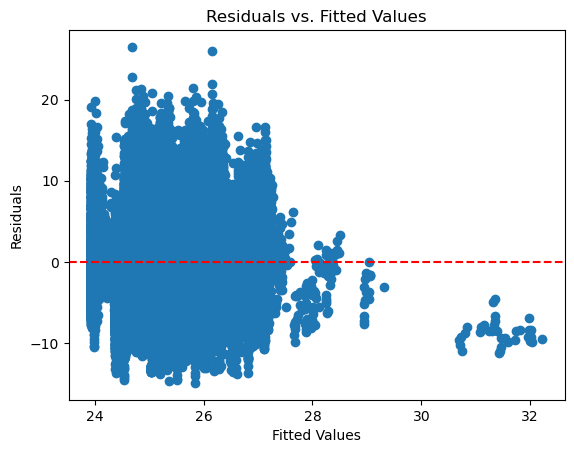

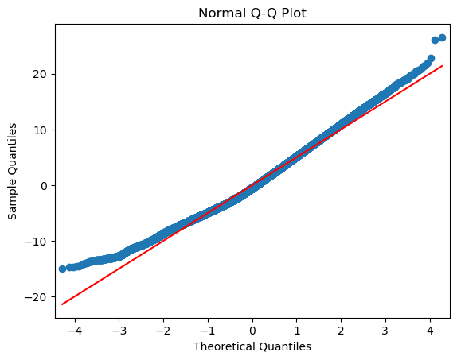

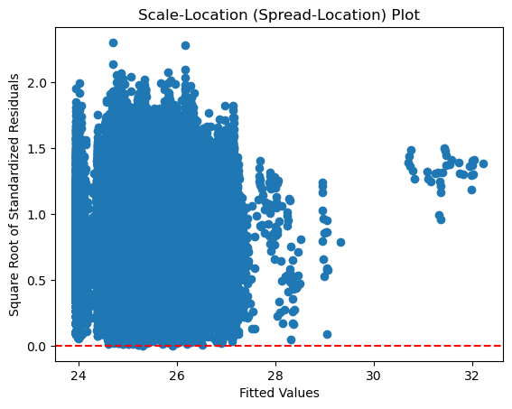

[figure not shown]

```python
# Validating for linearity assumptions

import statsmodels.api as sm
import matplotlib.pyplot as plt
import scipy.stats as stats
import numpy as np

# Assuming you have already fitted the linear regression model named 'model'

# Get fitted values and residuals
fitted_values = stats_model.fittedvalues
residuals = stats_model.resid

# 1. Residuals vs. Fitted Values Plot
plt.scatter(fitted_values, residuals)
plt.xlabel('Fitted Values')
plt.ylabel('Residuals')
plt.title('Residuals vs. Fitted Values')
plt.axhline(y=0, color='r', linestyle='--')  # Add a horizontal line at y=0
plt.show()

# 2. Normal Q-Q Plot
sm.qqplot(residuals, line='s')
plt.title('Normal Q-Q Plot')
plt.show()

# 3. Scale-Location (Spread-Location) Plot
sqrt_standardized_residuals = np.sqrt(np.abs(stats_model.get_influence().resid_studentized_internal))
plt.scatter(fitted_values, sqrt_standardized_residuals)
plt.xlabel('Fitted Values')
plt.ylabel('Square Root of Standardized Residuals')
plt.title('Scale-Location (Spread-Location) Plot')
plt.axhline(y=0, color='r', linestyle='--')  # Add a horizontal line at y=0
plt.show()

# 4. Residuals vs. Predictor Plot for ''
plt.scatter(df_obese_gender_pivot['Population'], residuals)
plt.xlabel('Population')
plt.ylabel('Residuals')
plt.title('Residuals vs. Tax Delta')
plt.axhline(y=0, color='r', linestyle='--')  # Add a horizontal line at y=0
plt.show()
```

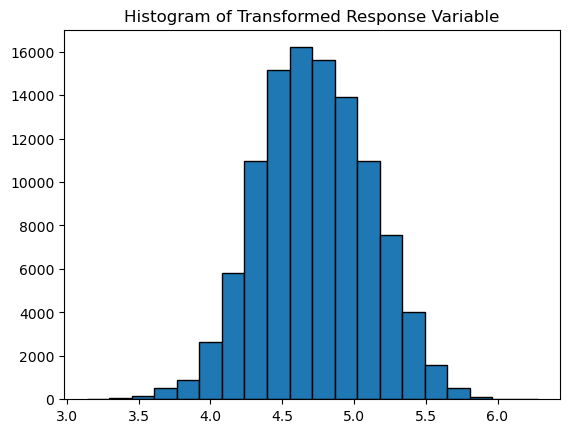

```
Lambda Value: 0.21498812940831752
                            OLS Regression Results
==============================================================================
Dep. Variable:                      y   R-squared:                       0.020
Model:                            OLS   Adj. R-squared:                  0.020
Method:                 Least Squares   F-statistic:                     544.4
Date:                Sun, 26 Nov 2023   Prob (F-statistic):               0.00
Time:                        07:39:44   Log-Likelihood:                -48366.
No. Observations:              106702   AIC:                         9.674e+04
Df Residuals:                  106697   BIC:                         9.679e+04
Df Model:                           4
Covariance Type:            nonrobust
==================================================================================
                     coef    std err          t      P>|t|      [0.025      0.975]
----------------------------------------------------------------------------------
const              4.6127      0.004   1160.205      0.000       4.605       4.620
Grocery Tax        1.3518      0.056     23.983      0.000       1.241       1.462
Restaurant Tax     1.0211      0.070     14.592      0.000       0.884       1.158
Population      1.346e-07   9.98e-09     13.493      0.000    1.15e-07    1.54e-07
Gender_Male        0.0780      0.002     33.467      0.000       0.073       0.083
==============================================================================
Omnibus:                      106.658   Durbin-Watson:                   0.405
Prob(Omnibus):                  0.000   Jarque-Bera (JB):               93.348
Skew:                           0.020   Prob(JB):                     5.37e-21
Kurtosis:                       2.861   Cond. No.                     7.55e+06
==============================================================================

Notes:
[1] Standard Errors assume that the covariance matrix of the errors is correctly specified.
[2] The condition number is large, 7.55e+06. This might indicate that there are
strong multicollinearity or other numerical problems.
```

```python
# Applying the Box-Cox transformation

# Apply Box-Cox Transformation to Response Variable
y_transformed, lambda_value = stats.boxcox(y + 1)  # Adding 1 to handle zero values

# Visualize the Transformed Response Variable
plt.hist(y_transformed, bins=20, edgecolor='black')
plt.title('Histogram of Transformed Response Variable')
plt.show()

# Check Lambda Value
print(f'Lambda Value: {lambda_value}')

# Fit a new model using the transformed response variable
stats_model_transformed = sm.OLS(y_transformed, X).fit()

# Print the summary of the transformed model
print(stats_model_transformed.summary())
```

##### Conclusion:

Since Adj. R square of this model is low, we will ignore further discussion

##### b. Total Population and Age - On Percentage

```python
import numpy as np
import pandas as pd
import statsmodels.api as sm
from sklearn.model_selection import train_test_split
from sklearn.linear_model import LinearRegression
from sklearn.metrics import mean_squared_error, r2_score

# Assuming 'Grocery Tax' and 'Restaurant Tax' are the features
X = pd.get_dummies(df_obese_age_pivot[['Grocery Tax', 'Restaurant Tax', 'Population','Age']], columns=['Age'], drop_first=True)
y = df_obese_age_pivot['Age Obesity Percentage']

# Add a constant term to the features matrix (required for statsmodels)
X = sm.add_constant(X)

# Create and fit the linear regression model using statsmodels
stats_model = sm.OLS(y, X).fit()

# Print the summary
print(stats_model.summary())
```

```
                              OLS Regression Results
==================================================================================
Dep. Variable:     Age Obesity Percentage   R-squared:                       0.281
Model:                                OLS   Adj. R-squared:                  0.281
Method:                     Least Squares   F-statistic:                 1.249e+04
Date:                    Sun, 26 Nov 2023   Prob (F-statistic):               0.00
Time:                            07:39:44   Log-Likelihood:            -4.8427e+05
No. Observations:                  159995   AIC:                         9.686e+05
Df Residuals:                      159989   BIC:                         9.686e+05
Df Model:                               5
Covariance Type:                nonrobust
==================================================================================
                     coef    std err          t      P>|t|      [0.025      0.975]
----------------------------------------------------------------------------------
const             22.5905      0.044    508.537      0.000      22.503      22.678
Grocery Tax       15.8791      0.603     26.331      0.000      14.697      17.061
Restaurant Tax    17.7805      0.749     23.738      0.000      16.312      19.249
Population      2.061e-06   1.49e-07     13.867      0.000    1.77e-06    2.35e-06
Age_45-64          5.6527      0.031    184.784      0.000       5.593       5.713
Age_65-beyond     -1.4773      0.031    -48.098      0.000      -1.537      -1.417
==============================================================================
Omnibus:                     4083.842   Durbin-Watson:                   0.269
Prob(Omnibus):                  0.000   Jarque-Bera (JB):             4404.096
Skew:                           0.406   Prob(JB):                         0.00
Kurtosis:                       2.964   Cond. No.                     5.40e+06
==============================================================================

Notes:
[1] Standard Errors assume that the covariance matrix of the errors is correctly specified.
[2] The condition number is large, 5.4e+06. This might indicate that there are
strong multicollinearity or other numerical problems.
```

##### Conclusion:

- One percent increase in grocery tax, keeping all other constant, increases the Obesity % by 15.87.
- One percent increase in restaurant tax, keeping all other constant, increases the Obesity % by 17.78.
- One unit increase in population, keeping all other constant, increases the Obesity % by 2.061 x 10^-6
- Adjusted R-square is 0.281 indicating that the model can explain only 28.1% of variation in % Obesity
- The conditional number is large and hence we need to check for multicollinearity
- This model has good R-square value but we need to validate the linearity assumptions and if any is violated, apply necessary trasformation

```python
# Checking for multicollinearity
from statsmodels.stats.outliers_influence import variance_inflation_factor

vif_data = pd.DataFrame()
vif_data["Variable"] = X.columns
vif_data["VIF"] = [variance_inflation_factor(X.values, i) for i in range(X.shape[1])]

# Check the VIF values
print(vif_data)
```

```
         Variable        VIF
0           const  12.668226
1     Grocery Tax   1.029672
2  Restaurant Tax   1.026495
3      Population   1.022988
4       Age_45-64   1.335252
5   Age_65-beyond   1.345333
```

##### Inference:

The VIF for predictor variables is small and hence multicollinearity does not exist The VIF with constant variable is high. This can be fixed by scaling if needed.

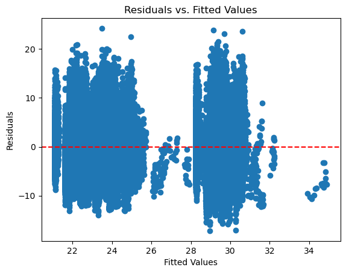

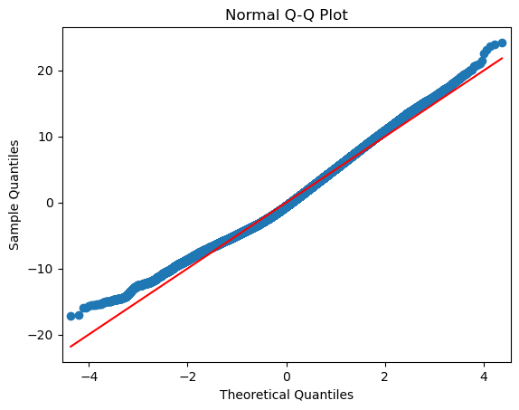

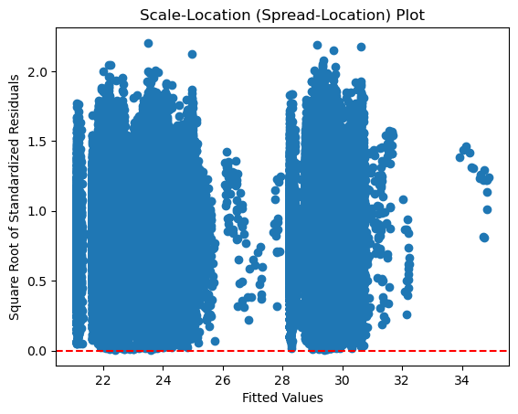

[figure not shown]

```python
# Validating for linearity assumptions

import statsmodels.api as sm
import matplotlib.pyplot as plt
import scipy.stats as stats
import numpy as np

# Assuming you have already fitted the linear regression model named 'model'

# Get fitted values and residuals
fitted_values = stats_model.fittedvalues
residuals = stats_model.resid

# 1. Residuals vs. Fitted Values Plot
plt.scatter(fitted_values, residuals)
plt.xlabel('Fitted Values')
plt.ylabel('Residuals')
plt.title('Residuals vs. Fitted Values')
plt.axhline(y=0, color='r', linestyle='--')  # Add a horizontal line at y=0
plt.show()

# 2. Normal Q-Q Plot
sm.qqplot(residuals, line='s')
plt.title('Normal Q-Q Plot')
plt.show()

# 3. Scale-Location (Spread-Location) Plot
sqrt_standardized_residuals = np.sqrt(np.abs(stats_model.get_influence().resid_studentized_internal))
plt.scatter(fitted_values, sqrt_standardized_residuals)
plt.xlabel('Fitted Values')
plt.ylabel('Square Root of Standardized Residuals')
plt.title('Scale-Location (Spread-Location) Plot')
plt.axhline(y=0, color='r', linestyle='--')  # Add a horizontal line at y=0
plt.show()

# 4. Residuals vs. Predictor Plot for ''
plt.scatter(df_obese_age_pivot['Population'], residuals)
plt.xlabel('Population')
plt.ylabel('Residuals')
plt.title('Residuals vs. Tax Delta')
plt.axhline(y=0, color='r', linestyle='--')  # Add a horizontal line at y=0
plt.show()
```

##### Since the above model violates linearity assumptions, applying Box-Cox transoformation

```python
# Applying the Box-Cox transformation

# Apply Box-Cox Transformation to Response Variable
y_transformed, lambda_value = stats.boxcox(y + 1)  # Adding 1 to handle zero values

# Visualize the Transformed Response Variable
plt.hist(y_transformed, bins=20, edgecolor='black')
plt.title('Histogram of Transformed Response Variable')
plt.show()

# Check Lambda Value
print(f'Lambda Value: {lambda_value}')

# Fit a new model using the transformed response variable
stats_model_transformed = sm.OLS(y_transformed, X).fit()

# Print the summary of the transformed model
print(stats_model_transformed.summary())
```

[output not shown]

```
Lambda Value: 0.14805832959442175
                            OLS Regression Results
==============================================================================
Dep. Variable:                      y   R-squared:                       0.276
Model:                            OLS   Adj. R-squared:                  0.276
Method:                 Least Squares   F-statistic:                 1.218e+04
Date:                Sun, 26 Nov 2023   Prob (F-statistic):               0.00
Time:                        07:39:50   Log-Likelihood:                -39487.
No. Observations:              159995   AIC:                         7.899e+04
Df Residuals:                  159989   BIC:                         7.904e+04
Df Model:                           5
Covariance Type:            nonrobust
==================================================================================
                     coef    std err          t      P>|t|      [0.025      0.975]
----------------------------------------------------------------------------------
const              4.0141      0.003   1456.579      0.000       4.009       4.020
Grocery Tax        1.0442      0.037     27.910      0.000       0.971       1.118
Restaurant Tax     1.0235      0.046     22.027      0.000       0.932       1.115
Population      1.384e-07   9.22e-09     15.010      0.000     1.2e-07    1.56e-07
Age_45-64          0.3376      0.002    177.871      0.000       0.334       0.341
Age_65-beyond     -0.1027      0.002    -53.876      0.000      -0.106      -0.099
==============================================================================
Omnibus:                      323.167   Durbin-Watson:                   0.290
Prob(Omnibus):                  0.000   Jarque-Bera (JB):              261.552
Skew:                          -0.001   Prob(JB):                     1.60e-57
Kurtosis:                       2.802   Cond. No.                     5.40e+06
==============================================================================

Notes:
[1] Standard Errors assume that the covariance matrix of the errors is correctly specified.
[2] The condition number is large, 5.4e+06. This might indicate that there are
strong multicollinearity or other numerical problems.
```

##### Conclusion:

- The lambda value is 0.14. Indicating the new model fit is on (((% Obesity^0.14)-1)/0.14). We will call this response as transformed y.
- One percent increase in grocery tax, keeping all other constant, increases the transformed y by 1.04
- One percent increase in restaurant tax, keeping all other constant, increases the transformed by 1.02.
- One unit increase in population, keeping all other constant, increases the transformed y by 1.38 x 10^-7.
- All p-value are statistically significant
- Adjusted R-square is 0.276 indicating that the model can explain only 27.6% of variation in % Obesity
- Conditonal large number error can be fixed by scaling

```python
import statsmodels.api as sm
from sklearn.preprocessing import StandardScaler
import pandas as pd

df_obese_scaled = df_obese_age_pivot.reset_index(drop=True)
df_obese_scaled

# Extract the independent variables (features) from your DataFrame
X = pd.get_dummies(df_obese_scaled[['Grocery Tax', 'Restaurant Tax','Population', 'Age']], columns=['Age'], drop_first=True)
# Extract the dependent variable from your DataFrame
y = df_obese_scaled['Age Obesity Percentage']

# Initialize the StandardScaler
scaler = StandardScaler()

# Fit and transform the independent variables
X_scaled = scaler.fit_transform(X)

# Create a new DataFrame with the scaled features
X_scaled_df = pd.DataFrame(X_scaled, columns=X.columns)

# Add a constant term to the independent variables
X_scaled_df = sm.add_constant(X_scaled_df)

# Fit the linear regression model
model = sm.OLS(y, X_scaled_df).fit()

# Display the summary
print(model.summary())
```

```
                              OLS Regression Results
==================================================================================
Dep. Variable:     Age Obesity Percentage   R-squared:                       0.281
Model:                                OLS   Adj. R-squared:                  0.281
Method:                     Least Squares   F-statistic:                 1.249e+04
Date:                    Sun, 26 Nov 2023   Prob (F-statistic):               0.00
Time:                            07:39:51   Log-Likelihood:            -4.8427e+05
No. Observations:                  159995   AIC:                         9.686e+05
Df Residuals:                      159989   BIC:                         9.686e+05
Df Model:                               5
Covariance Type:                nonrobust
==================================================================================
                     coef    std err          t      P>|t|      [0.025      0.975]
----------------------------------------------------------------------------------
const             25.1611      0.012   2015.967      0.000      25.137      25.186
Grocery Tax        0.3335      0.013     26.331      0.000       0.309       0.358
Restaurant Tax     0.3002      0.013     23.738      0.000       0.275       0.325
Population         0.1750      0.013     13.867      0.000       0.150       0.200
Age_45-64          2.6650      0.014    184.784      0.000       2.637       2.693
Age_65-beyond     -0.6963      0.014    -48.098      0.000      -0.725      -0.668
==============================================================================
Omnibus:                     4083.842   Durbin-Watson:                   0.269
Prob(Omnibus):                  0.000   Jarque-Bera (JB):             4404.096
Skew:                           0.406   Prob(JB):                         0.00
Kurtosis:                       2.964   Cond. No.                         1.75
==============================================================================

Notes:
[1] Standard Errors assume that the covariance matrix of the errors is correctly specified.
```

##### Since the above model violates linearity assumptions, applying Box-Cox transformation to scaled parameters

```python
# Applying the Box-Cox transformation

# Apply Box-Cox Transformation to Response Variable
y_transformed, lambda_value = stats.boxcox(y + 1)  # Adding 1 to handle zero values

# Visualize the Transformed Response Variable
plt.hist(y_transformed, bins=20, edgecolor='black')
plt.title('Histogram of Transformed Response Variable')
plt.show()

# Check Lambda Value
print(f'Lambda Value: {lambda_value}')

# Fit a new model using the transformed response variable
stats_model_transformed = sm.OLS(y_transformed, X_scaled_df).fit()

# Print the summary of the transformed model
print(stats_model_transformed.summary())
```

[output not shown]

```
Lambda Value: 0.14805832959442175
                            OLS Regression Results
==============================================================================
Dep. Variable:                      y   R-squared:                       0.276
Model:                            OLS   Adj. R-squared:                  0.276
Method:                 Least Squares   F-statistic:                 1.218e+04
Date:                Sun, 26 Nov 2023   Prob (F-statistic):               0.00
Time:                        07:39:52   Log-Likelihood:                -39487.
No. Observations:              159995   AIC:                         7.899e+04
Df Residuals:                  159989   BIC:                         7.904e+04
Df Model:                           5
Covariance Type:            nonrobust
==================================================================================
                     coef    std err          t      P>|t|      [0.025      0.975]
----------------------------------------------------------------------------------
const              4.1624      0.001   5375.803      0.000       4.161       4.164
Grocery Tax        0.0219      0.001     27.910      0.000       0.020       0.023
Restaurant Tax     0.0173      0.001     22.027      0.000       0.016       0.019
Population         0.0118      0.001     15.010      0.000       0.010       0.013
Age_45-64          0.1591      0.001    177.871      0.000       0.157       0.161
Age_65-beyond     -0.0484      0.001    -53.876      0.000      -0.050      -0.047
==============================================================================
Omnibus:                      323.167   Durbin-Watson:                   0.290
Prob(Omnibus):                  0.000   Jarque-Bera (JB):              261.552
Skew:                          -0.001   Prob(JB):                     1.60e-57
Kurtosis:                       2.802   Cond. No.                         1.75
==============================================================================

Notes:
[1] Standard Errors assume that the covariance matrix of the errors is correctly specified.
```

##### Conclusion:

- The lambda value is 0.14. Indicating the new model fit is on (((% Obesity^0.14)-1)/0.14). We will call this response as transformed y.
- One percent increase in scaled grocery tax, keeping all other constant, increases the transformed y by 0.02
- One percent increase in scaled restaurant tax, keeping all other constant, increases the transformed by 0.01.
- One unit increase in population, keeping all other constant, increases the transformed y by 0.01.
- All p-value are statistically significant
- Adjusted R-square is 0.276 indicating that the model can explain only 27.6% of variation in % Obesity

### Final Conclusion:

- The best model for Obesity % variation with Tax, after accounting for necessary controls and corrections of assumptions, is the model with response, (((% Obesity^0.14)-1)/0.14); and scaled predictor grocery tax, restaurant tax; and population and age control
- This model explains for 27.6% variability in Obesity %
- We shall continue to research the impact by variation on tax delta.